# submission-notebook

### Imports and SetUp

```python
import shutup; shutup.please()
import numpy as np
import torch
import matplotlib.pyplot as plt
import torchvision
import torch.nn.functional as F
import random
import shap
import cv2

from torchvision import transforms
from torch.utils.data import DataLoader

import sys
import os

# Adding the utils
module_path = os.path.abspath("ex2_cifar10_aaron")
if module_path not in sys.path:
    sys.path.append(module_path)

from cifar10_utils import Net, load_data, im_show, train_model, test_model, load_saved_model, test_model
```

```python
if torch.cuda.is_available():
    device = torch.device("cuda")
    print(f"Using CUDA: {torch.cuda.get_device_name(0)}")
elif torch.backends.mps.is_available():
    device = torch.device("mps")
    print("Using Metal Performance Shaders (MPS)")
else:
    device = torch.device("cpu")
    print("Using CPU")
```

```
Using CPU
```

### Load Dataset

The CIFAR-10 dataset is a collection of 60,000 32x32 color images in 10 classes, with 6,000 images per class. The classes include **airplane**, **automobile**, **bird**, **cat**, **deer**, **dog**, **frog**, **horse**, **ship**, and **truck**. It is widely used for benchmarking machine learning algorithms in computer vision.

In this section, we load the CIFAR-10 dataset using the `load_data` function, which performs the following operations:

1. **Transforms**: The dataset images are transformed to tensors and normalized. The normalization helps to bring all pixel values into a standard range, which can accelerate training and improve model performance.
2. **Data Splitting**: The function loads both the training, validation and test set. We use only the test set in this script for our analysis.
3. **Batch Size**: A batch size of 1 is used, which allows us to focus on individual images for generating and visualizing saliency maps. This setup makes it easier to understand the impact of each pixel on the model’s prediction.

```python
# Load CIFAR-10 data
_, _, test_loader = load_data(batch_size=1)  # Batch size of 1 for saliency
classes = ['airplane', 'automobile', 'bird', 'cat', 'deer', 'dog', 'frog', 'horse', 'ship', 'truck']

# For SHAP analysis, create a DataLoader with batch_size=10
_, _, test_loader_shap = load_data(batch_size=10)  # Batch size of 10 for SHAP
```

```
Files already downloaded and verified
Files already downloaded and verified
Files already downloaded and verified
Files already downloaded and verified
```

### Load Model

In this section, we load our trained model to evaluate the CIFAR-10 dataset. The `load_saved_model` function loads the state dictionary into a new instance of the model, which is then used for generating saliency maps to explain the predictions.

### Information about the Model

```python
# Load trained model
model = load_saved_model(Net, filepath='ex2_cifar10_aaron/model_cifar.pt', device=device)
model.eval().to(device)
```

```
Model loaded successfully from ex2_cifar10_aaron/model_cifar.pt
```

```
Net(
  (conv_layer): Sequential(
    (0): Conv2d(3, 32, kernel_size=(3, 3), stride=(1, 1), padding=(1, 1))
    (1): BatchNorm2d(32, eps=1e-05, momentum=0.1, affine=True, track_running_stats=True)
    (2): ReLU(inplace=True)
    (3): Conv2d(32, 64, kernel_size=(3, 3), stride=(1, 1), padding=(1, 1))
    (4): ReLU(inplace=True)
    (5): MaxPool2d(kernel_size=2, stride=2, padding=0, dilation=1, ceil_mode=False)
    (6): Conv2d(64, 128, kernel_size=(3, 3), stride=(1, 1), padding=(1, 1))
    (7): BatchNorm2d(128, eps=1e-05, momentum=0.1, affine=True, track_running_stats=True)
    (8): ReLU(inplace=True)
    (9): Conv2d(128, 128, kernel_size=(3, 3), stride=(1, 1), padding=(1, 1))
    (10): ReLU(inplace=True)
    (11): MaxPool2d(kernel_size=2, stride=2, padding=0, dilation=1, ceil_mode=False)
    (12): Dropout2d(p=0.05, inplace=False)
    (13): Conv2d(128, 256, kernel_size=(3, 3), stride=(1, 1), padding=(1, 1))
    (14): BatchNorm2d(256, eps=1e-05, momentum=0.1, affine=True, track_running_stats=True)
    (15): ReLU(inplace=True)
    (16): Conv2d(256, 256, kernel_size=(3, 3), stride=(1, 1), padding=(1, 1))
    (17): ReLU(inplace=True)
    (18): MaxPool2d(kernel_size=2, stride=2, padding=0, dilation=1, ceil_mode=False)
  )
  (fc_layer): Sequential(
    (0): Dropout(p=0.1, inplace=False)
    (1): Linear(in_features=4096, out_features=1024, bias=True)
    (2): ReLU(inplace=True)
    (3): Linear(in_features=1024, out_features=512, bias=True)
    (4): ReLU(inplace=True)
    (5): Dropout(p=0.1, inplace=False)
    (6): Linear(in_features=512, out_features=10, bias=True)
  )
)
```

### Model Explanation Technique 1: Saliency Maps

Saliency maps are a popular technique used for visualizing which parts of an input image contribute most to a model's decision. In the context of convolutional neural networks (CNNs), saliency maps provide insight into which pixels in an image influence the predicted class the most.

The idea behind saliency maps is to compute the gradient of the output class score with respect to the input image. This gradient tells us how much each pixel in the image would need to change to affect the predicted score the most. By taking the absolute maximum gradient across color channels, we can visualize which areas of the image the model finds most relevant for classification.

In this notebook, we generate saliency maps by:

1. **Setting `requires_grad` to True**: We enable gradient calculation for the input image tensor, allowing us to perform backpropagation from the output back to the input.
2. **Computing Loss and Backpropagating**: We compute the loss for the correct class label and backpropagate it through the network. This process calculates the gradients with respect to each pixel in the image.
3. **Visualizing the Gradient Magnitude**: The resulting gradient is visualized as a saliency map. The intensity of each pixel in the saliency map indicates how important it was for the model’s decision. Brighter regions in the saliency map imply that those parts of the image were more influential in determining the output.

Saliency maps provide an effective way to understand the inner workings of deep learning models, offering insight into what the network "sees" as important when making predictions.

```python
# Function to generate saliency map
def generate_saliency_map(model, image, label, device):
    image = image.to(device)
    image.requires_grad_()  # Set requires_grad to True to calculate gradients

    # Forward pass
    output = model(image)

    # Get the predicted class
    pred_class = output.argmax().item()

    # Calculate the loss for the correct class
    loss = F.nll_loss(F.log_softmax(output, dim=1), label.to(device))

    # Backward pass
    model.zero_grad()
    loss.backward()

    # Get saliency map
    saliency, _ = torch.max(image.grad.data.abs(), dim=1)
    return saliency.cpu().squeeze(), pred_class
```

```python
# Function to display an image and its saliency map
def display_saliency(image, saliency, pred_class, true_class):
    image = image / 2 + 0.5  # Unnormalize image
    image_np = np.transpose(image.detach().numpy(), (1, 2, 0))

    return image_np, saliency, pred_class, true_class
```

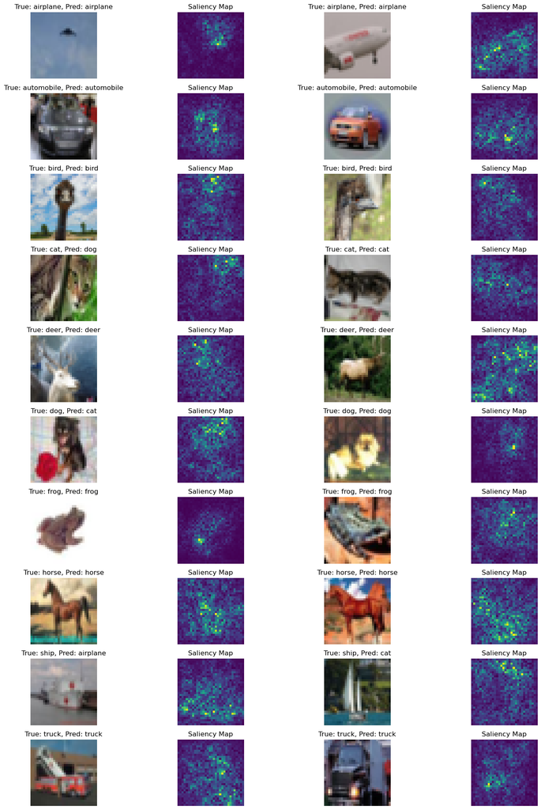

```python
# Iterate over the test set and visualize saliency maps for multiple examples per class
class_examples = {cls: 0 for cls in range(10)}  # Track examples per class
examples_per_class = 2  # Number of examples to show per class

fig, axes = plt.subplots(10, 4, figsize=(16, 20))  # 10 rows for classes, 4 columns (2 pairs of image and saliency per row)
current_row = 0

# Randomly shuffle the data to get different examples each time
all_data = list(test_loader)
random.shuffle(all_data)

# Sort data by class to ensure rows contain the same class
sorted_data = {cls: [] for cls in range(10)}
for data, target in all_data:
    true_class = target.item()
    if class_examples[true_class] < examples_per_class:
        sorted_data[true_class].append((data, target))
        class_examples[true_class] += 1
    if all(len(v) >= examples_per_class for v in sorted_data.values()):
        break

# Plot saliency maps for each class
for true_class in range(10):
    current_col = 0
    for data, target in sorted_data[true_class]:
        saliency, predicted_class = generate_saliency_map(model, data, target, device)
        image_np, saliency_map, pred_class, true_class = display_saliency(data[0].cpu(), saliency, predicted_class, true_class)

        # Plot the original image
        ax = axes[current_row, current_col]
        ax.imshow(image_np)
        ax.axis('off')
        ax.set_title(f'True: {classes[true_class]}, Pred: {classes[pred_class]}')

        # Plot the saliency map
        ax = axes[current_row, current_col + 1]
        ax.imshow(saliency_map, cmap=plt.cm.viridis)
        ax.axis('off')
        ax.set_title('Saliency Map')

        current_col += 2

    current_row += 1

plt.tight_layout()
plt.show()
```

#### Interpretation of Results

1. **Key Observations**:
   - The saliency maps successfully highlight regions corresponding to the object in the image (e.g., car, bird, or plane).
   - Due to the low resolution of the CIFAR-10 images (32x32 pixels), fine details are hard to distinguish, leading to blurred importance regions.
   - The method is effective for identifying general regions of importance but lacks detailed insights into specific learned features.
2. **Limitations**:
   - The low resolution of the CIFAR-10 dataset restricts the clarity and interpretability of saliency maps.
   - As a gradient-based method, saliency maps can sometimes be noisy or fail to capture complex patterns.
   - They serve as a good starting point but should ideally be complemented with other techniques like Grad-CAM or integrated gradients for richer explanations.
   - Saliency maps assume that the gradient at a specific pixel is directly interpretable, but CNN decisions are complex and nonlinear. This simplification might not capture the true multi-layered reasoning of the network.
3. **Utility**:
   - Provides a quick visual check of model behavior.
   - Helps debug whether the model is focusing on meaningful parts of the input or irrelevant noise.

### Model Explanation Technique 2: SHAP (SHapley Additive exPlanations)

```python
# Helper function to preprocess input for SHAP
def preprocess_input(data):
    # Normalize the images as the model expects
    transform = transforms.Compose([
        transforms.ToTensor(),
        transforms.Normalize((0.5, 0.5, 0.5), (0.5, 0.5, 0.5))
    ])
    return torch.stack([transform(img) for img in data])

# Helper function for SHAP predictions
def model_predict(data):
    data = torch.tensor(data, dtype=torch.float32).permute(0, 3, 1, 2)
    data = data.contiguous().to(device)
    # Normalize data
    data = transforms.Normalize((0.5, 0.5, 0.5), (0.5, 0.5, 0.5))(data)
    with torch.no_grad():
        preds = model(data)
        probs = torch.nn.functional.softmax(preds, dim=1)  # Convert to probabilities
    return probs.cpu().numpy()
```

```python
# Prepare a subset of test images for SHAP analysis
dataiter = iter(test_loader_shap)
images, labels = next(dataiter)
images = images.permute(0, 2, 3, 1).numpy()  # Convert from (N, C, H, W) to (N, H, W, C)

# Define the masker
masker = shap.maskers.Image("blur(128,128)", images[0].shape)  # Pass shape as (H, W, C)

# Initialize SHAP explainer
explainer = shap.Explainer(model_predict, masker)

# Compute SHAP values
shap_values = explainer(images[:10])  # Use first 10 images

# Check the shape of SHAP values
print(f"Shape of shap_values: {[v.shape for v in shap_values.values]}")
```

```
Shape of shap_values: [(32, 32, 3, 10), (32, 32, 3, 10), (32, 32, 3, 10), (32, 32, 3, 10), (32, 32, 3, 10), (32, 32, 3, 10), (32, 32, 3, 10), (32, 32, 3, 10), (32, 32, 3, 10), (32, 32, 3, 10)]
```

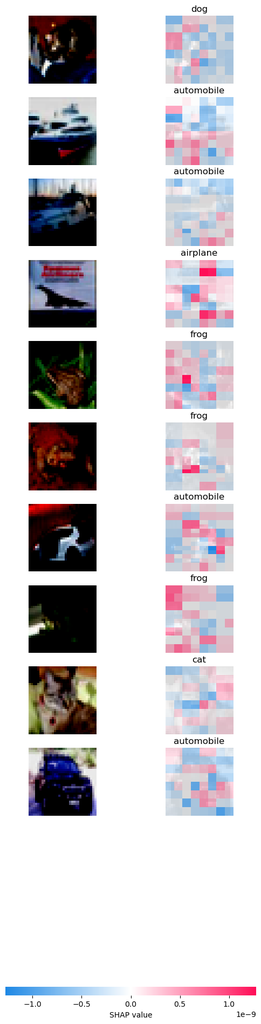

```python
# Define class labels (reuse 'classes' variable from earlier)
class_labels = classes

# Model predictions for first 10 images
predictions = np.argmax(model_predict(images[:10]), axis=1)

# Use predictions for labeling
labels = np.array([class_labels[pred] for pred in predictions]).reshape(-1, 1)  # Make it 2D for SHAP

# Flatten SHAP values for visualization (sum over the class dimension)
shap_values_flattened = [v.sum(-1) for v in shap_values.values]  # Sum over the class dimension

# Convert SHAP values into a single array of shape (N, H, W)
shap_values_array = np.array(shap_values_flattened)

# Ensure images are in [0, 1] range
images_normalized = np.clip(images[:10], 0, 1)

# Plot SHAP values
shap.image_plot(
    shap_values_array,  # SHAP values in (N, H, W)
    images_normalized,  # Input images in (N, H, W, C)
    labels=labels       # Predicted class labels
)
```

### Model Explanation Technique 3: Invertible Concept-based Explanations

The technique is implemented manually and implementation details can be found in ncav_utils.py and ConceptExtractor.py

We will use batch zero for training the reducer (retrieving the concepts) and then evaluate the concepts on the whole test dataset. We choose the last activation layer as this provides higher level features.

```python
# Additional imports for ICE
from sklearn.metrics.pairwise import cosine_similarity
from ConceptExtractor import ConceptExtractor
from ncav_utils import calc_concept_number, TCAV, calc_avg_concept_presence, plot_concept_images

model_ice = load_saved_model(filepath='ex2_cifar10_aaron/model_cifar.pt', device=device)
model_ice.save_act = True

_, _, test_loader_ice = load_data(batch_size=512)

# Retrive the activations from all model layers of the test dataset
activations = test_model(model_ice, test_loader_ice, device, True)

# Prepare activation layer for NMF
A = activations[0]["conv17"]  # Shape: batch_size, channels, height, width
# Reshape A to batch_size, height, width, channels
A = np.transpose(A, (0, 2, 3, 1))
```

```
Model loaded successfully from ex2_cifar10_aaron/model_cifar.pt
Files already downloaded and verified
Files already downloaded and verified
Test Loss: 0.543699

Test Accuracy of airplane: 88.90%
Test Accuracy of automobile: 92.00%
Test Accuracy of bird : 77.80%
Test Accuracy of cat  : 64.30%
Test Accuracy of deer : 80.70%
Test Accuracy of dog  : 80.20%
Test Accuracy of frog : 84.70%
Test Accuracy of horse: 81.80%
Test Accuracy of ship : 87.90%
Test Accuracy of truck: 87.60%
Test Accuracy (Overall): 82.59%
```

```python
# Test forward from specific layer function
model_ice.eval()
with torch.no_grad():
    output1 = model_ice.forward_from_layer(torch.from_numpy(activations[0]["conv17"]), start_layer=18)
    output2 = torch.from_numpy(activations[0]["fc6"])
    assert np.all(output1.detach().numpy() == output2.detach().numpy()), "outputs do not coincide"
```

```python
def calc_concept_number(thresholds: list, A, init_concepts):

    concept_dict_all_classes = {threshold: [None, None] for threshold in thresholds}

    for threshold in thresholds:
        print(f"threshold: {threshold}")
        ConceptExtractor_activations = ConceptExtractor(A, seed=1234)
        concepts = init_concepts
        similar_concepts = True
        while similar_concepts and concepts > 0:
            # Train NMF
            ConceptExtractor_activations.apply_NMF(nr_concepts=concepts)
            # Extract the P matrix where the rows correspond to the CAVs
            P = ConceptExtractor_activations.P
            # Calculate the cosine similarity between the CAVs
            cos_sim = cosine_similarity(P)
            # Extract the upper triangle, excluding the diagonal to get the similarities beteen CAVs
            cos_sim = np.triu(cos_sim, k=1)
            # Check if all the CAVs are below the threshold
            above_threshold = cos_sim > threshold
            if above_threshold.sum() == 0:
                similar_concepts = False
                concept_dict_all_classes[threshold][0] = concepts
                concept_dict_all_classes[threshold][1] = P
            else:
                concepts -= 1
    return concept_dict_all_classes

# Calculate the best concept number

thresholds = [0.1, 0.2, 0.25, 0.3, 0.4, 0.5]
init_concepts = 30

# Prepare activation layer for NMF
A = activations[0]["conv17"]  # shape: batch_size, channels, height, width
# Reshape A to batch_size, height, width, channels
A = np.transpose(A, (0, 2, 3, 1))

concept_dict_all_classes = calc_concept_number(thresholds, A, init_concepts)
```

```
threshold: 0.1
threshold: 0.2
threshold: 0.25
threshold: 0.3
threshold: 0.4
threshold: 0.5
```

```python
for key in concept_dict_all_classes.keys():
    print(f"Similarity Threshold {key} : optimal number of concepts : {concept_dict_all_classes[key][0]}")
```

```
Similarity Threshold 0.1 : optimal number of concepts : 1
Similarity Threshold 0.2 : optimal number of concepts : 1
Similarity Threshold 0.25 : optimal number of concepts : 28
Similarity Threshold 0.3 : optimal number of concepts : 30
Similarity Threshold 0.4 : optimal number of concepts : 30
Similarity Threshold 0.5 : optimal number of concepts : 30
```

As it can be seen here, when the threshold is low, we enforce the concepts to be more dissimilar as the maximum similarity must be below the threshold. Consequently, by enforcing dissimilar concepts, the optimal number is smaller. However for our dataset, these calculated "optimal concepts" seem not to be helpful in analyzing meaningful concepts. Either, we have only one concept, which is intuitively too small for ten different classes or we have lots of concepts which is too big to get an intuition for the method.

We still have a look at the TCAV scores for all thresholds for all concepts as they might already give us some intuition about a potential redundancy of some concepts (e.g. if serveral concepts only appear for a specific class). To measure how sensitive a single image or a class is with respect to a specific concept, the directional derivative of the logit for a specific sample in the direction of the CAV is used. Whenever this derivative is positive, the concept is useful for classifying a sample as a specific class. To obtain the TCAV score for a concept, [(Kim et al. 2018)](https://arxiv.org/abs/1711.11279) simply calculate the fraction of directional derivatives for a set of images where a CAV has a positive influence on the prediciton.

A TCAV score of 1 indicates that the model uses a certain concept for making the predictions for all images from the set and conversely, a score of 0 implies the concept is not present in any of the images.

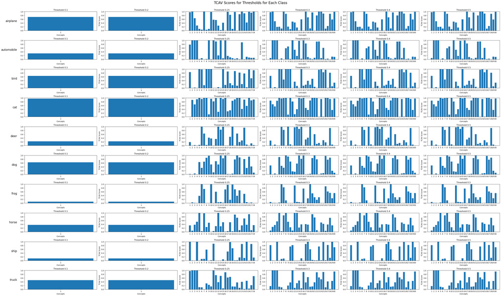

```python
row_titles = ['airplane', 'automobile', 'bird', 'cat', 'deer', 'dog', 'frog', 'horse', 'ship', 'truck']

fig, axes = plt.subplots(nrows=10, ncols=len(thresholds), figsize=(40, 24))

# prepare activation layer
A = activations[0]["conv17"] # shape: batch_size, channels, height, width
A = np.transpose(A, (0, 2, 3, 1))

for i in range(10):
    for j in range(len(thresholds)):
        cav_scores = TCAV(A,
                       layer_name = 18,
                       P = concept_dict_all_classes[thresholds[j]][1],
                       epsilon = 1e-6,
                       model = model_ice,
                       class_k = i)
        x_values = range(len(cav_scores))
        x_labels = [i+1 for i in range(len(cav_scores))]
        axes[i, j].bar(x_values, cav_scores, color='C0')
        axes[i, j].set_xticks(x_values, x_labels)
        axes[i, j].set_xlabel('Concepts')
        axes[i, j].set_ylabel('TCAV Score')
        axes[i, j].set_ylim(0, 1)
        axes[i, j].set_title(f'Threshold {thresholds[j]}')

    # Set the headline for the row (class title)
    axes[i, 0].set_ylabel(row_titles[i], rotation=0, fontsize=16, labelpad=20, ha='right', va='center')

# Adjust layout to prevent overlap
plt.tight_layout(rect=[0, 0, 1, 0.96])  # Adjust rect to leave space for class titles

plt.suptitle('TCAV Scores for Thresholds for Each Class', fontsize=20)

plt.show()
```

To enable a better analysis of concepts, we will now fix the number of concepts to 10. And calculate 10 concepts for the last convolutional layer.

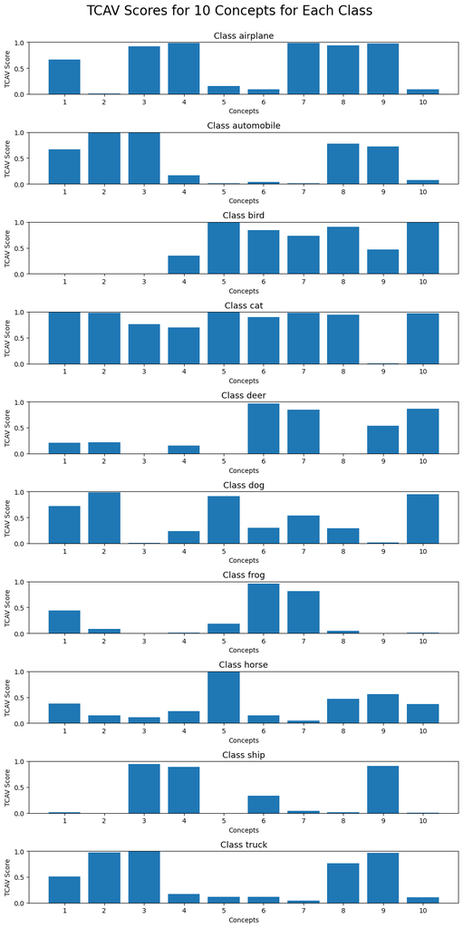

```python
# prepare activation layer
A = activations[0]["conv17"] # shape: batch_size, channels, height, width
# reshape A to batch_size, height, width, channels
A = np.transpose(A, (0, 2, 3, 1))

ConceptExtractor_activations = ConceptExtractor(A, seed=1234)

# train NMF
ConceptExtractor_activations.apply_NMF(nr_concepts=10)

col_titles = ['airplane', 'automobile', 'bird', 'cat', 'deer', 'dog', 'frog', 'horse', 'ship', 'truck']

fig, axes = plt.subplots(nrows=10, ncols=1, figsize=(10, 20))

for i, ax in enumerate(axes):
    cav_scores = TCAV(torch.from_numpy(A),
                   layer_name = 18,
                   P = ConceptExtractor_activations.P,
                   epsilon = 1e-6,
                   model = model_ice,
                   class_k = i)
    x_values = range(len(cav_scores))
    x_labels = [i+1 for i in range(len(cav_scores))]
    ax.bar(x_values, cav_scores, color='C0')
    ax.set_xticks(x_values, x_labels)
    ax.set_xlabel('Concepts')
    ax.set_ylabel('TCAV Score')
    ax.set_ylim(0, 1)
    ax.set_title(f'Class {col_titles[i]}', fontsize=13)

    # Set the headline for the row (class title)
   # axes[i, 0].set_ylabel(row_titles[i], rotation=0, fontsize=16, labelpad=20, ha='right', va='center')

# Adjust layout to prevent overlap
plt.tight_layout()  # Adjust rect to leave space for class titles

plt.suptitle('TCAV Scores for 10 Concepts for Each Class', fontsize=20)
plt.subplots_adjust(hspace=0.5)
plt.tight_layout(rect=[0, 0, 1, 0.98])

plt.show()
```

| Concept | High Class TCAV Scores |
| --- | --- |
| 1 | Airplane, Automobile, Cat, (Dog) |
| 2 | Automobile, Cat, Dog, Truck |
| 3 | Airplane, Automobile, (Cat), Ship, Truck |
| 4 | Airplane, (Cat), Ship |
| 5 | Bird, Cat, Dog, Horse |
| 6 | Bird, Cat, Deer, Frog |
| 7 | Airplane, (Bird), Cat, Deer, Frog |
| 8 | Airplane, (Automobile), Bird, Cat, (Truck) |
| 9 | Airplane, (Automobile), (Deer), Ship, Truck |
| 10 | Bird, Cat, Deer, Dog |

When looking at the Class TCAV scores, we gain some insights in what the concepts might look like that we extracted.

- Concepts 3, 9: Mostly activated for means of transportation
- Concept 4: primarily activated for Airplanes and Ships (they might have similar colors: white with blue sky/water)
- Concepts 5, 6, 10: are only activated for animals However, we also cannot infer more than this since lots of the concepts activate very different classes (see Concepts 1 & 2 as examples).

To gain even further information about the extracted concepts, we calculate the average concept presence for each CAV from the feature scores S that hold the information on how strong a concept is present in a particular image. We retrieve the top 5 images with the highest/lowest presence for each concept to gain insights into the learned concepts. The concepts in range (0, 1) are thresholded to be larger than 0.5 and their respective heatmaps are overlaid onto the original images. Brighter regions indicate a higher presence.

```python
Explainer_S = []

for batch_idx, (data, target) in enumerate(test_loader_ice):
    # extract the activation layer of this batch
    A = activations[batch_idx]["conv17"]
    A = np.transpose(A, (0, 2, 3, 1))
    # apply the explainer (the already fitted NMF model)
    S = ConceptExtractor_activations.explainer(A, batch_size=data.shape[0])
    Explainer_S.append(S)

avg_concept_presence = calc_avg_concept_presence(5, Explainer_S, test_loader_ice, ConceptExtractor_activations)
```

```python
Explainer_S_all = []
heatmaps = []

for batch_idx, (data, target) in enumerate(test_loader_ice):
    S = Explainer_S[batch_idx].copy()
    S = S.reshape((
        data.shape[0],
        ConceptExtractor_activations.height,
        ConceptExtractor_activations.width,
        ConceptExtractor_activations.nr_concepts
    ))

    S_reshaped = S.copy()
    S_reshaped = np.transpose(S_reshaped, (0, 3, 1, 2)) #needed for interpolating S: batch_size x channels x height x width
    # heatmap size fits our log mel spectrograms, if others are used, then change size
    heatmap_batch = torch.nn.functional.interpolate(torch.from_numpy(S_reshaped), size=(32, 32), mode='bilinear', align_corners=False)

    # normalize the heatmaps
    normalized_heatmaps = np.zeros_like(heatmap_batch, dtype=np.float32)

    for b in range(data.shape[0]):
        for c in range(ConceptExtractor_activations.nr_concepts):
            img_concept = heatmap_batch[b, c, :, :]
            min_val = torch.min(img_concept)
            max_val = torch.max(img_concept)

            normalized_img_concept = (img_concept - min_val) / (max_val - min_val)

            # thresholding the heatmaps s.t. concepts are larger than threshold
            #normalized_img_concept[normalized_img_concept < threshold] = 0
            normalized_heatmaps[b, c, :, :] = normalized_img_concept

    flattened_batch = [S[i] for i in range(S.shape[0])]
    Explainer_S_all.extend(flattened_batch)
    flattened_batch = [normalized_heatmaps[i] for i in range(normalized_heatmaps.shape[0])]
    heatmaps.extend(flattened_batch)
```

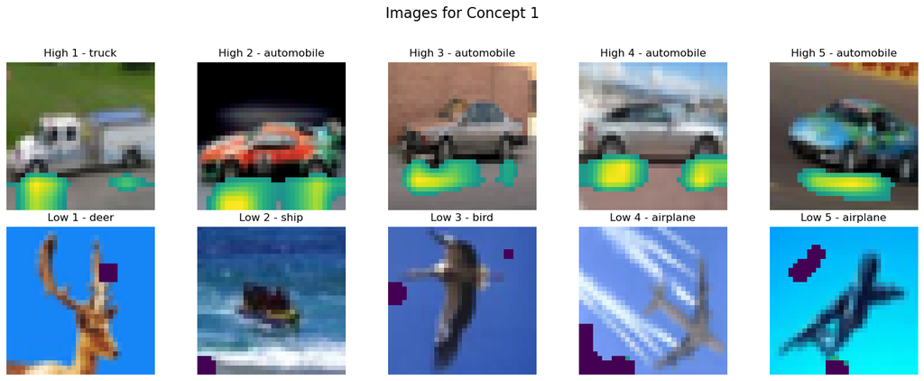

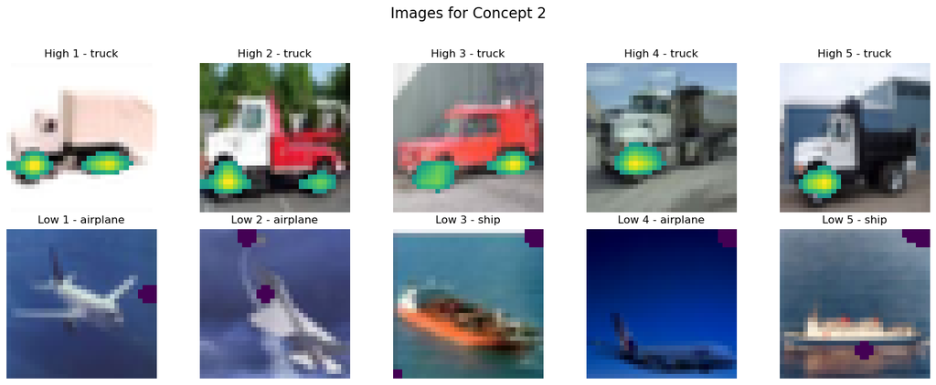

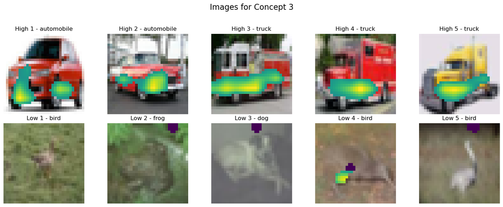

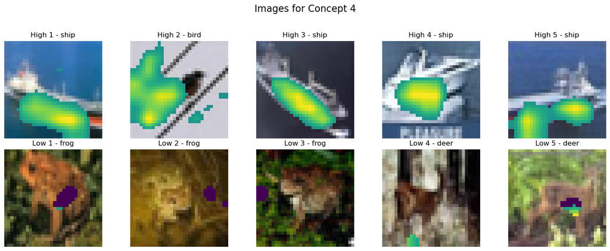

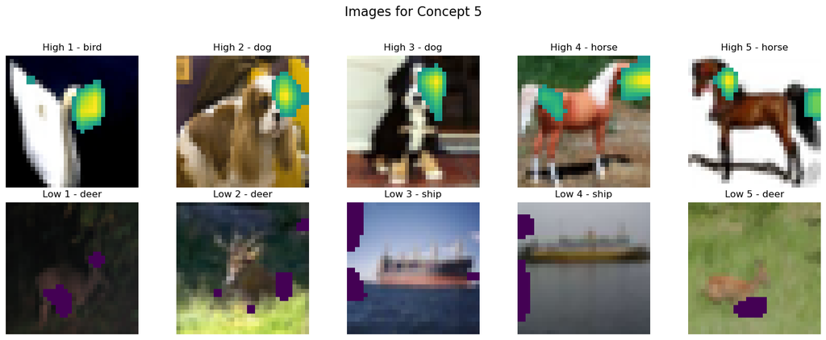

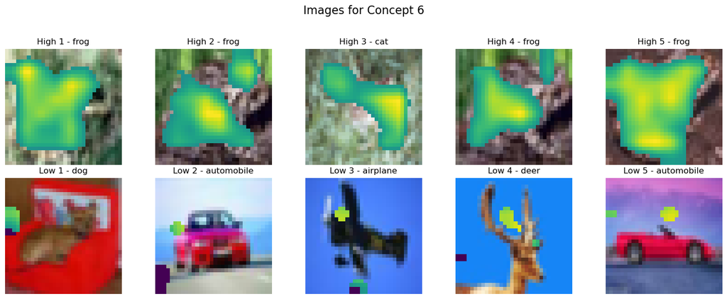

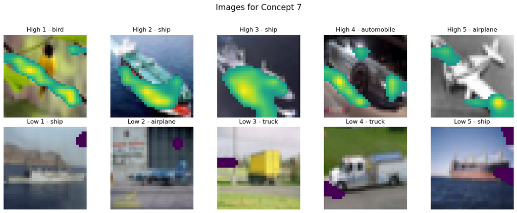

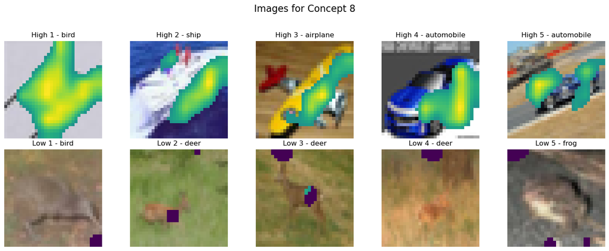

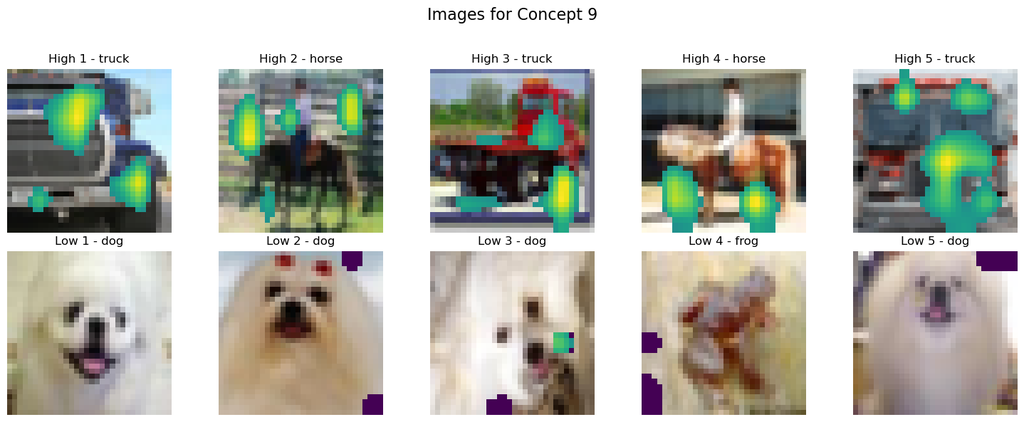

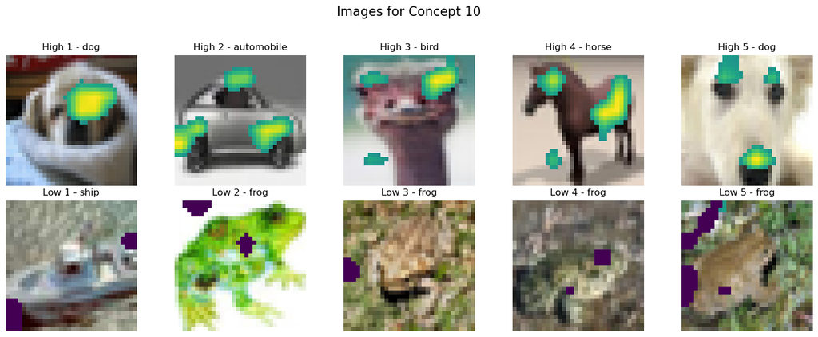

```python
plot_concept_images(avg_concept_presence, test_loader_ice, S=heatmaps, threshold=0.5, background_alpha=0.4)
```

| Concept | Concept Description (inferred from plotted images) |
| --- | --- |
| 1 | Concrete floor |
| 2 | Wheels of vehicles |
| 3 | Front part of cars (headlights) |
| 4 | unclear, maybe contrast between white and black/blue |
| 5 | eye of animals |
| 6 | particular brown-ish color (resembling frogs or fur color) |
| 7 | unclear, maybe black lines |
| 8 | unclear, maybe color in specific area |
| 9 | unclear, maybe shiny image parts |
| 10 | regions above black spots (like eyes) |

From the plotted images we can infer some concepts. However other cannot be indentified clearly.  
In addition, the concepts primarily focus on color, some are also location specific (like concrete floor).

#### Interpretation of Results

1. **Key Observations**:
   - Invertible Concept-based Explanations is able to extract (some) meaningful concepts that our CNN has learned. With this, it becomes clear why the model performs better for the means of transportation: their concepts are much more nuanced and meaningful as other concepts. E.g. for vehicles, the concrete floor or wheels are correctly identified. For animal classes, the focus is more on basic colors.
   - The method allowed us to explore the learned concepts in an unbiased way which is advantageous when the true underlying concepts are unknown.
2. **Limitations**:
   - Due to the hyperparameter selection of the number of concepts, we restrict our concept discovery a lot. Because the true underlying number is unknown, we are not able to recover all concepts that the model has learned. Analysis of 10 concepts might have been too little concepts or too many and thus, we cannot fully understand the model.
   - In addition, the lack of concept labels makes it sometimes very difficult to understand the extracted concepts (as seen above). Plotting the highest concept presence and lowest concept presence images helps to identify what the might (not) be. However, this is not an exact determination.
   - Moreover, to extract meaningful concepts, it is important that the model has acutally learned to classify samples well. In our case, we can see that the concepts are not specific and clear for classes, where the CNN has a lower accuracy.
3. **Utility**:
   - The method helps us to understand how a model learns to discrimiate between classes. Sometimes, it only looks at color patterns (Concept 6) which explains a lower accuracy for animal classes as this is a redunant feature.
   - With this, we know what parts the CNN is lacking and could provide specific training examples that help to improve model performance for specific classes. In addition, we also see if there is a potential bias in the dataset the model learns without understanding the class itself.
4. **Answers to the Research Questions**:
   - What parts of an image are important to classify an image? The CNN looks for some classes at specific parts (for vehicles), for other classes, the colors are more important. In addition, the CNN not only looks at the objects itself but also uses their surroundings for making a prediction.
   - What patterns/structures has our model learned? It focuses a lot on colors, and the combination of colors. Besides, locations and shapes are also relevant (e.g. Concept 2 describing wheels)
   - What difficulties does the CNN have when correctly predicting specific images/classes? The CNN had problems for classes where it has not learned discriminative concepts and simply relies on color patterns to make a prediction.

### Model Explanation Technique 4: InstanceFlow

#### Visualizing the Evolution of Classifier Confusion on the Instance Level

```python
# load data
train_loader, valid_loader, _ = load_data(withid=True)
_, _, test_loader = load_data(withid=False)

# specify the image classes
classes = ['airplane', 'automobile', 'bird', 'cat', 'deer', 'dog', 'frog', 'horse', 'ship', 'truck']
```

```
Files already downloaded and verified
Files already downloaded and verified
Files already downloaded and verified
Files already downloaded and verified
```

```
Epoch: 0 	Training Loss: 1.224166 	Validation Loss: 0.222554
Validation loss decreased (inf --> 0.222554). Saving model...
Epoch: 1 	Training Loss: 0.783593 	Validation Loss: 0.165815
Validation loss decreased (0.222554 --> 0.165815). Saving model...
Epoch: 2 	Training Loss: 0.606585 	Validation Loss: 0.144934
Validation loss decreased (0.165815 --> 0.144934). Saving model...
Epoch: 3 	Training Loss: 0.498721 	Validation Loss: 0.135917
Validation loss decreased (0.144934 --> 0.135917). Saving model...
Epoch: 4 	Training Loss: 0.417896 	Validation Loss: 0.128064
Validation loss decreased (0.135917 --> 0.128064). Saving model...
Epoch: 5 	Training Loss: 0.352466 	Validation Loss: 0.155027
Epoch: 6 	Training Loss: 0.294475 	Validation Loss: 0.110531
Validation loss decreased (0.128064 --> 0.110531). Saving model...
Epoch: 7 	Training Loss: 0.242500 	Validation Loss: 0.116798
Epoch: 8 	Training Loss: 0.196187 	Validation Loss: 0.116064
Epoch: 9 	Training Loss: 0.156672 	Validation Loss: 0.128416
Epoch: 10 	Training Loss: 0.124627 	Validation Loss: 0.120625
Epoch: 11 	Training Loss: 0.101879 	Validation Loss: 0.131581
Epoch: 12 	Training Loss: 0.085061 	Validation Loss: 0.141534
Epoch: 13 	Training Loss: 0.069531 	Validation Loss: 0.143900
Epoch: 14 	Training Loss: 0.057374 	Validation Loss: 0.138616
Epoch: 15 	Training Loss: 0.049436 	Validation Loss: 0.147357
Epoch: 16 	Training Loss: 0.044094 	Validation Loss: 0.150653
Epoch: 17 	Training Loss: 0.040045 	Validation Loss: 0.135673
Epoch: 18 	Training Loss: 0.034174 	Validation Loss: 0.149727
Epoch: 19 	Training Loss: 0.029713 	Validation Loss: 0.152278
Epoch: 20 	Training Loss: 0.028903 	Validation Loss: 0.150525
Epoch: 21 	Training Loss: 0.026726 	Validation Loss: 0.149962
Epoch: 22 	Training Loss: 0.020862 	Validation Loss: 0.161762
Epoch: 23 	Training Loss: 0.023006 	Validation Loss: 0.153183
Epoch: 24 	Training Loss: 0.020072 	Validation Loss: 0.175101
Epoch: 25 	Training Loss: 0.020031 	Validation Loss: 0.168960
Epoch: 26 	Training Loss: 0.019025 	Validation Loss: 0.162772
Epoch: 27 	Training Loss: 0.015710 	Validation Loss: 0.179225
Epoch: 28 	Training Loss: 0.017336 	Validation Loss: 0.170084
Epoch: 29 	Training Loss: 0.012444 	Validation Loss: 0.176998
```

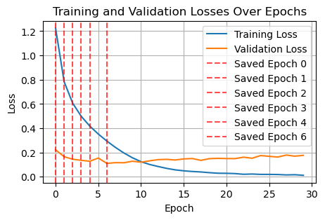

```python
# initialize and train model
model = Net()
if_result = train_model(model, train_loader, valid_loader, device, n_epochs=30, lr=0.01, instanceflow=True, plot=True)
train_losses, train_ground_truth, train_predictions, val_ground_truth, val_predictions = if_result
```

Saving the collected data in the right format

```python
import json

def saveInstanceFlowJSON(name, ground_truth, predictions):

    # basic InstanceFlowJSON structure
    iflowdict = {"name": name, "labels": None, "instances": None, "epochs": None}
    iflowdict["labels"] = [
        'airplane', 'automobile', 'bird', 'cat', 'deer', 'dog', 'frog', 'horse', 'ship', 'truck'
    ]

    # transforming and adding the ground truth instances
    iflowdict["instances"] = [
        {"id": f"{key:04d}", "actual": value, "image": ""}
        for key, value in zip(ground_truth.keys(), ground_truth.values())
    ]

    # transforming and adding the predictions for all epochs
    iflowdict["epochs"] = [
        {"id": str(epoch), "classifications": list(preds.values())}
        for epoch, preds in enumerate(predictions)
    ]

    # save InstanceFlowJSON to file
    with open(f"{iflowdict['name']}.json", "w") as outfile:
        json.dump(iflowdict, outfile, indent=4)

# save collected train data to InstanceFlowJSON file
saveInstanceFlowJSON("iflowcifar10_train", train_ground_truth, train_predictions)
# save collected validation data to InstanceFlowJSON file
saveInstanceFlowJSON("iflowcifar10_val", val_ground_truth, val_predictions)
```

If we evaluate the model on the test set, we can see a big difference of the models ability to make correct predictions for the different classes.

```python
test_model(model, test_loader, device)
```

```
Test Loss: 0.868667

Test Accuracy of airplane: 77.80%
Test Accuracy of automobile: 92.70%
Test Accuracy of bird : 77.00%
Test Accuracy of cat  : 70.90%
Test Accuracy of deer : 86.30%
Test Accuracy of dog  : 80.40%
Test Accuracy of frog : 89.70%
Test Accuracy of horse: 83.00%
Test Accuracy of ship : 89.50%
Test Accuracy of truck: 91.40%
Test Accuracy (Overall): 83.87%
```

The class that performs the worst is "cat".

We can use InstanceFlow to get insights into why this might be the case.

The following coloring scheme is used:

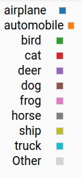

For this we first look at the Sankey diagram just for the class "cat" for the first 8 epochs.

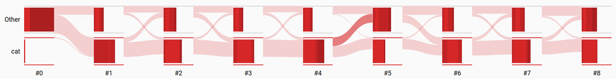

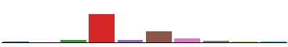

If we now add the "dog" and "frog" classes to the visualization.

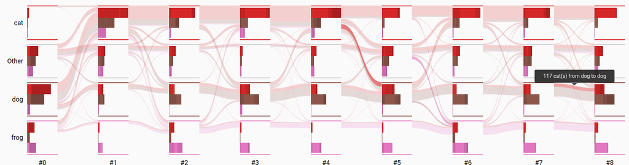

We can see that there is a flow of cats after the 5th epoch that get misclassified as dogs. And multiple after the 6th epoch that get misclassified as "frog".

We now zoom in and only consider epochs 4 to 6.

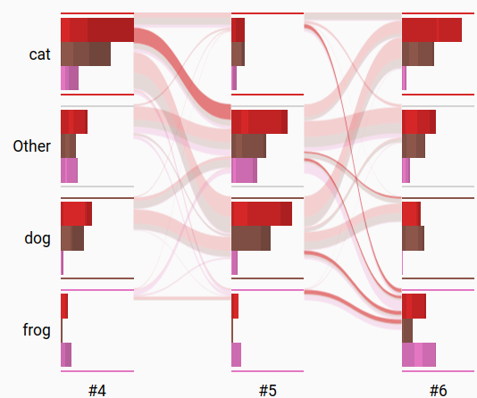

If we now click on the flow between the 4th and 5th epoch, we can see all the misclassifications in the table below.

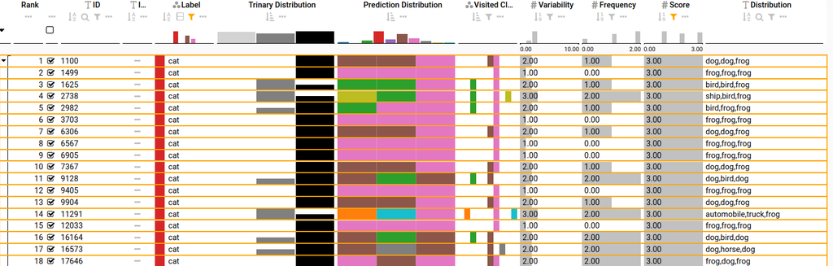

We can now look at some of these misclassified images and see their similarity to dogs/frogs.

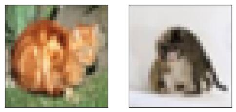

```python
valid_dataset = valid_loader.dataset

images = [valid_dataset[idx][0] for idx in [1100, 7367]]

fig = plt.figure(figsize=(6, 3))
for idx, image in enumerate(images):
    ax = fig.add_subplot(1, 2, idx+1, xticks=[], yticks=[])
    im_show(image)
```

#### Interpretation of Results

1. **Key Observations**:
   - We can clearly see the learning behavior of the model over time
   - We could visualize over all classes and epochs. However, this will lead to a messy end result that is difficult to interpret and hard to work with.
   - Starting with a broad evaluation of the model and then iteratively refining it to narrow down why it behaves in a certain way is a better approach.
   - The method is effective in getting key insight regarding the classifications of even individual instances.
2. **Limitations**:
   - As already mentioned above. If we have a multiclass classification problem with lots of classes over many epochs, visualizing everything at once can lead to a messy end result that is difficult to interpret and hard to work with.
   - To visualize the flow of an instance, we must evaluate the model on it after each epoch. For a new instance, we would have to either retrain the model while evaluating it or save the model after each epoch and then evaluate on these saved instances.
3. **Utility**:
   - Provides a quick visual check of model behavior during training
   - But it can also be used to debug it on a class or even an instant level.